[O’Hara on GitHub](https://github.com/oharac)

# Map cumulative impacts from uniform-exposure stressors

Compiled on Sun Sep 17 16:22:46 2023 by ohara

```r
knitr::opts_chunk$set(echo = TRUE, message = FALSE, warning = FALSE, fig.height = 4, fig.width = 7)

library(terra)
library(oharac)
library(data.table)
library(tidyverse)
library(here)
source(here('common_fxns.R'))
```

# 1 Summary

For most stressors, exposure is identical across all species and taxa, like nutrient pollution, light pollution, etc (as opposed to targeted fishing, bycatch, or thermal stress where the stressor intensity is dependent on the species). For these stressors, with vulnerability maps by unweighted and FV-weighted mean, we can calculate impacts simply by multiplying mean vulnerability and stressor intensity. For species-dependent stressors, see scripts 4a, 4b, and 4c.

# 2 Data

See scripts 2, 3a, and 3b for vulnerability mapping scripts.

# 3 Methods

## 3.1 Determine stressor and vulnerability matchups

Note: because there are no benthic structures in our data for BC, we will manually remove it here.

```r
str_vuln_lookup_f <- here('_raw/stressor_vulnerability_lookup.csv')

str_vuln_lookup_raw <- read_csv(str_vuln_lookup_f)
knitr::kable(str_vuln_lookup_raw)
```

| stressor | vulnerability | stressor_group |
| --- | --- | --- |
| biomass_removal | biomass_removal | fishing |
| sst_rise | sst_rise | climate |
| bycatch | bycatch | fishing |
| sst_extremes | marine_heat_waves | climate |
| ocean_acidification | ocean_acidification | climate |
| sea_level_rise | sea_level_rise | climate |
| uv_radiation | uv_radiation | climate |
| fishing_benthic_dest | habitat_loss_degradation | fishing |
| benth_str | habitat_loss_degradation | ocean_based |
| direct_human | habitat_loss_degradation | land_based |
| shipping_large | wildlife_strike | ocean_based |
| light | light_pollution | land_based |
| nutrient | eutrophication_nutrient_pollution | land_based |

```r
str_vuln_lookup <- str_vuln_lookup_raw %>%
  filter(!stressor %in% c('biomass_removal', 'bycatch', 'sst_rise', 'benth_str'))
```

Exposure to stressors `biomass_removal`, `sst_rise`, and `bycatch` are not uniform across all species, and will need to be dealt with in a more complex manner when calculating impact.

## 3.2 Read in stressor layers

These do not change based on different vulnerability weighting schemes…

```r
str_fs <- list.files(here('_data/stressors_bc'), full.names = TRUE)
str_fs <- str_fs[str_detect(str_fs, paste(str_vuln_lookup$stressor, collapse = '|'))]

str_stack <- terra::rast(str_fs) %>%
  setNames(basename(str_fs) %>% str_remove('_[0-9]{4}.tif'))
```

## 3.3 Impacts by unweighted mean vulnerability

Using the average vulnerability value across all species, calculate impacts by stressor and overall.

### 3.3.1 Loop over stressors

For each line in the above listing, determine the impact (mean and sd) of that stressor on the suite of species in each cell, based on that vulnerability.

```r
vuln_string <- paste(str_vuln_lookup$vulnerability, collapse = '|')

vuln1_mean_fs <- list.files(here_anx('_output/vuln_maps/vuln_maps_by_species'),
                            pattern = 'mean.tif', full.names = TRUE)
vuln1_mean_fs <- vuln1_mean_fs[str_detect(vuln1_mean_fs, vuln_string)]

vuln1_mean_stack <- terra::rast(vuln1_mean_fs) %>%
  setNames(basename(vuln1_mean_fs) %>% str_remove_all('vuln_spp_|_mean.tif'))

vuln1_sd_fs <- list.files(here_anx('_output/vuln_maps/vuln_maps_by_species'),
                          pattern = 'sdev.tif', full.names = TRUE)
vuln1_sd_fs <- vuln1_sd_fs[str_detect(vuln1_sd_fs, vuln_string)]

vuln1_sd_stack <- terra::rast(vuln1_sd_fs) %>%
  setNames(basename(vuln1_sd_fs) %>% str_remove_all('vuln_spp_|_sdev.tif'))
```

```r
for(i in 1:nrow(str_vuln_lookup)) {
  ### i <- 6
  s <- str_vuln_lookup$stressor[i]
  v <- str_vuln_lookup$vulnerability[i]

  f_stem <- here_anx('_output/impact_maps/impact_maps_species',
                 'impact_spp_%s_x_%s_%s.tif')
  f_out  <- sprintf(f_stem, s, v, c('mean', 'sdev'))

  if(any(!file.exists(f_out))) {
    message('Calculating mean/sd impacts for stressor ', s, ' by vuln ', v, '...')

    s_rast <- str_stack[[s]]
    v_mean_rast <- vuln1_mean_stack[[v]]
    v_sdev_rast <- vuln1_sd_stack[[v]]
    i_mean_rast <- s_rast * v_mean_rast
    i_sdev_rast <- s_rast * v_sdev_rast
    # values(i_rast) <- round(values(i_rast), 5)

    writeRaster(i_mean_rast, f_out[1], overwrite = TRUE)
    writeRaster(i_sdev_rast, f_out[2], overwrite = TRUE)
  }

  # p <- s_v_i_plot(s_rast, v_rast, i_rast, flag = 'unweighted all')

  # print(p)
}
```

```r
imp_map_dir <- here_anx('_output/impact_maps/impact_maps_species')
imp_map_fs <- list.files(imp_map_dir, pattern = '_mean.tif', full.names = TRUE)

focal_strs <- str_vuln_lookup$stressor %>% unique()

for(f in focal_strs) { ### f <- focal_strs[1]
  str_name <- str_replace_all(f, '[^a-z]+', ' ') %>%
    str_squish() %>%
    str_to_title()

  message('Plotting impact maps for ', tolower(str_name), '...')
  imp_map_f <- imp_map_fs[str_detect(basename(imp_map_fs), f)]
  imp_rast <- terra::rast(imp_map_f)

  map_cols <- hcl.colors(n = 50)

  plot(imp_rast, col = map_cols,
       main = paste0('Impact, unweighted vuln: ', f),
       legend = TRUE, axes = FALSE)
}
```

[output not shown]

## 3.4 Impacts by FV-weighted vulnerability

Using the FV-weighted vulnerability value, calculate impacts by stressor and overall.

```r
vuln2_mean_fs <- list.files(here_anx('_output/vuln_maps/vuln_maps_by_funct_entity'),
                       pattern = 'mean.tif', full.names = TRUE)
vuln2_mean_fs <- vuln2_mean_fs[str_detect(vuln2_mean_fs, vuln_string)]

vuln2_mean_stack <- terra::rast(vuln2_mean_fs) %>%
  setNames(basename(vuln2_mean_fs) %>% str_remove_all('vuln_fe_|_mean.tif'))

vuln2_sd_fs <- list.files(here_anx('_output/vuln_maps/vuln_maps_by_funct_entity'),
                       pattern = 'sdev.tif', full.names = TRUE)
vuln2_sd_fs <- vuln2_sd_fs[str_detect(vuln2_sd_fs, vuln_string)]

vuln2_sd_stack <- terra::rast(vuln2_sd_fs) %>%
  setNames(basename(vuln2_sd_fs) %>% str_remove_all('vuln_fe_|_sdev.tif'))
```

```r
for(i in 1:nrow(str_vuln_lookup)) {
  ### i <- 1
  s <- str_vuln_lookup$stressor[i]
  v <- str_vuln_lookup$vulnerability[i]

  f_stem <- here_anx('_output/impact_maps/impact_maps_funct_entity',
                 'impact_fe_%s_x_%s_%s.tif')
  f_out  <- sprintf(f_stem, s, v, c('mean', 'sdev'))

  if(any(!file.exists(f_out))) {
    message('Calculating FV-weighted mean/sd impacts for stressor ', s,
            ' by vuln ', v, '...')

    s_rast <- str_stack[[s]]
    v_mean_rast <- vuln2_mean_stack[[v]]
    v_sdev_rast <- vuln2_sd_stack[[v]]
    i_mean_rast <- s_rast * v_mean_rast
    i_sdev_rast <- s_rast * v_sdev_rast
    # values(i_rast) <- round(values(i_rast), 5)

    writeRaster(i_mean_rast, f_out[1], overwrite = TRUE)
    writeRaster(i_sdev_rast, f_out[2], overwrite = TRUE)
  }
}
```

```r
imp_map_dir <- here_anx('_output/impact_maps/impact_maps_funct_entity')
imp_map_fs <- list.files(imp_map_dir, pattern = 'mean.tif', full.names = TRUE)

focal_strs <- str_vuln_lookup$stressor %>% unique()

for(f in focal_strs) { ### f <- focal_strs[1]
  str_name <- str_replace_all(f, '[^a-z]+', ' ') %>%
    str_squish() %>%
    str_to_title()

  message('Plotting impact maps for ', tolower(str_name), '...')
  imp_map_f <- imp_map_fs[str_detect(basename(imp_map_fs), f)]
  imp_rast <- raster::raster(imp_map_f)

  map_cols <- hcl.colors(n = 50)

  plot(imp_rast, col = map_cols,
       main = paste0('Impact, FV-weighted vuln: ', f),
       legend = TRUE, axes = FALSE)
}
```

[output not shown]

## 3.5 Difference maps

Loop over several focal stressors. For each stressor, read in the maps of unweighted mean impact $\bar x$ and fv-weighted mean impact $\bar x_{FV}$. Calculate difference as proportional difference in FV-weighted mean relative to unweighted mean impact:
$$diff = (\bar x_{FV} - \bar x) / \bar
x$$

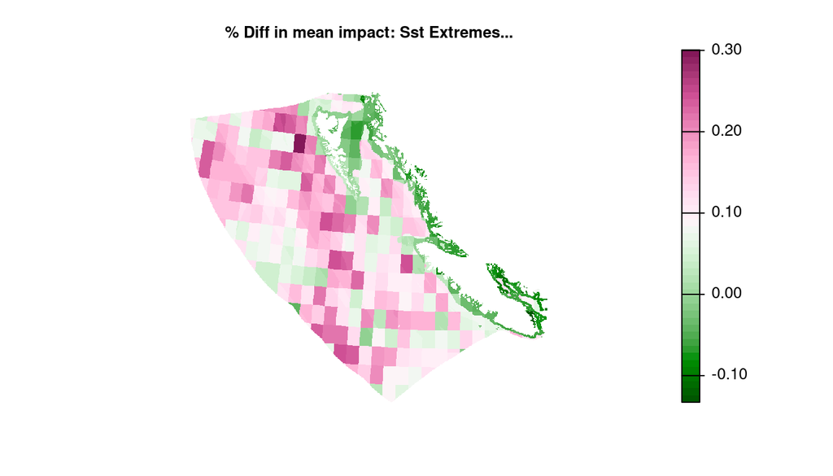

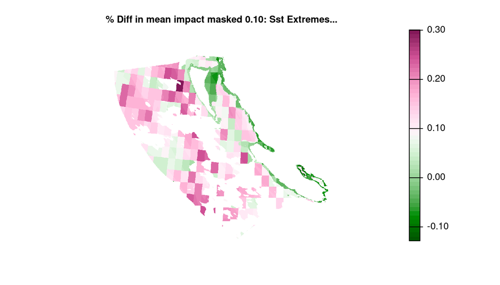

[figure not shown]

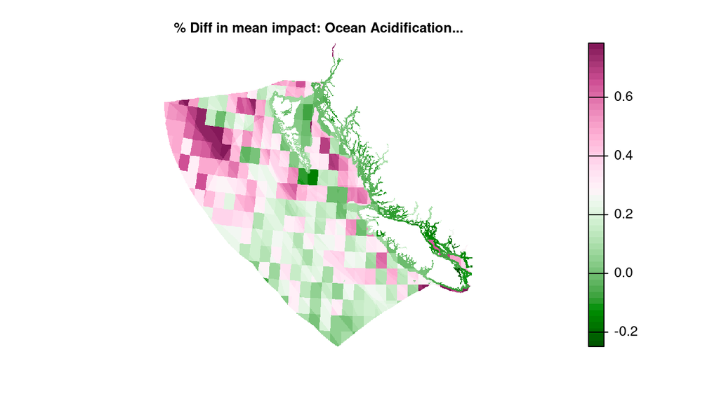

[figure not shown]

[figure not shown]

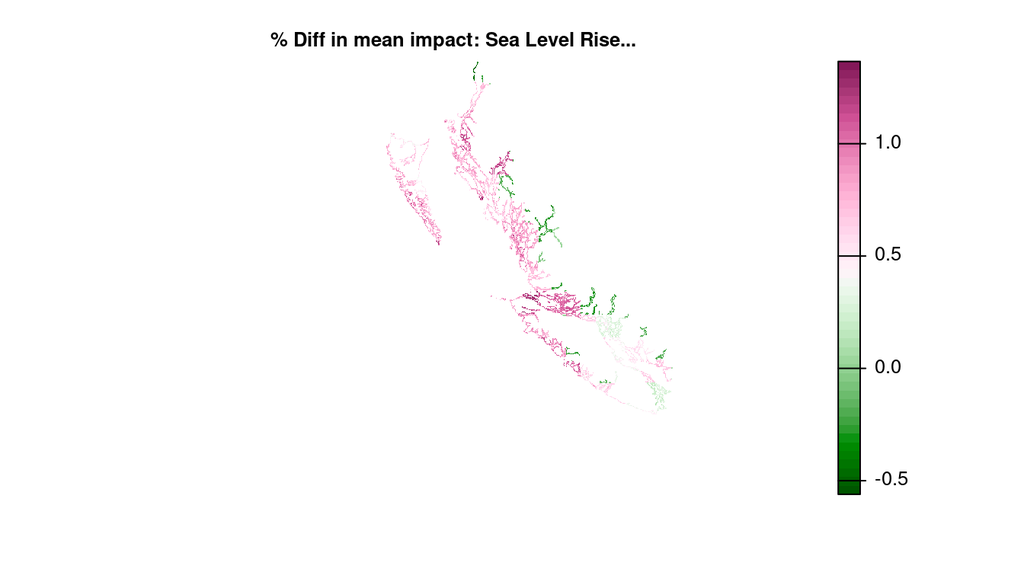

[figure not shown]

[figure not shown]

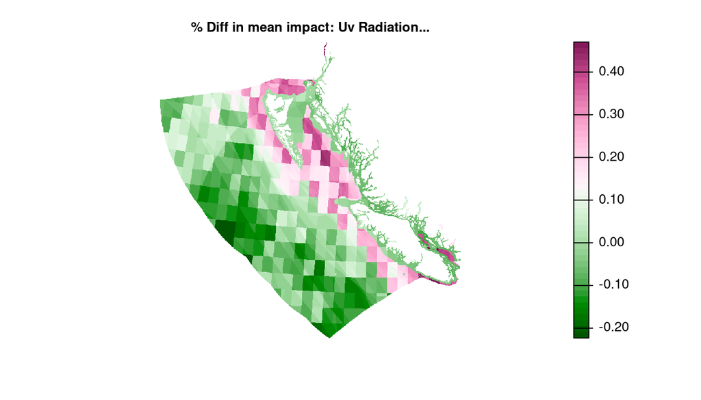

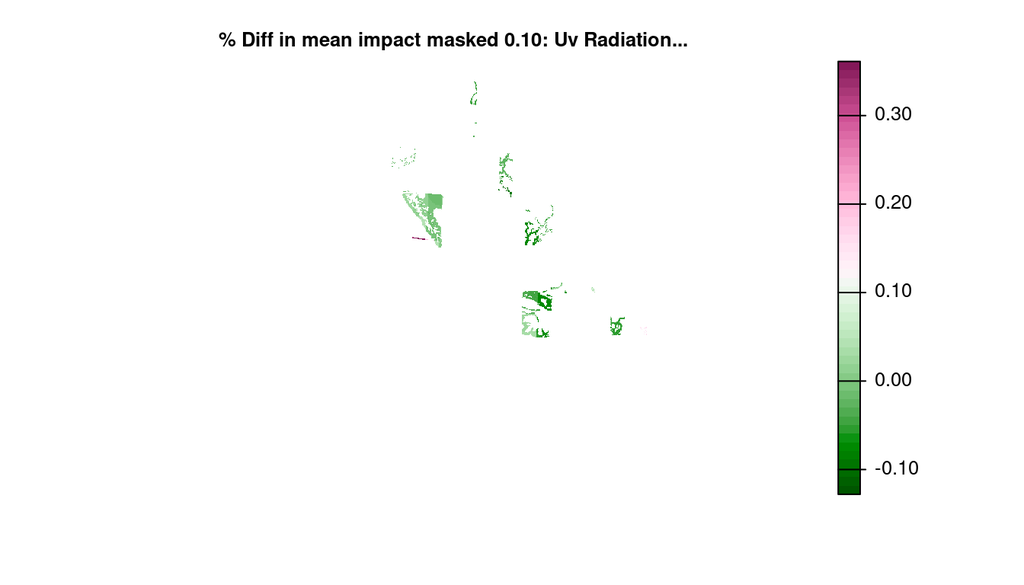

[figure not shown]

[15 more figures not shown]

```r
squish_rast <- function(r, qtile = .999) {
  r_vals <- values(r); r_vals <- r_vals[!is.na(r_vals)]
  r_zlim <- max(abs(quantile(r_vals, 1 - qtile)), abs(quantile(r_vals, qtile)))
  values(r)[values(r) > r_zlim] <- r_zlim
  values(r)[values(r) < -r_zlim] <- -r_zlim

  return(list(r = r, zlim = r_zlim))
}

focal_strs <- str_vuln_lookup$stressor %>% unique()

mean_unwt_fs <- list.files(here_anx('_output/impact_maps/impact_maps_species'),
                           pattern = '_mean.tif', full.names = TRUE)
mean_fvwt_fs <- list.files(here_anx('_output/impact_maps/impact_maps_funct_entity'),
                           pattern = '_mean.tif', full.names = TRUE)

ocean_mask <- terra::rast(here('_spatial/ocean_bc_1km.tif'))

for(f in focal_strs) { ### f <- focal_strs[5]
  str_name <- str_replace_all(f, '[^a-z]+', ' ') %>%
    str_squish() %>%
    str_to_title()

  unwt_f <- mean_unwt_fs[str_detect(mean_unwt_fs, f)]
  fvwt_f <- mean_fvwt_fs[str_detect(mean_fvwt_fs, f)]

  if(length(unwt_f) > 1) {
    unwt_r <- terra::rast(unwt_f) %>%
      sum(na.rm = TRUE) %>%
      mask(ocean_mask)
    fvwt_r <- terra::rast(fvwt_f) %>%
      sum(na.rm = TRUE) %>%
      mask(ocean_mask)
  } else {
    unwt_r <- terra::rast(unwt_f)
    fvwt_r <- terra::rast(fvwt_f)
  }

  ### Set up rasters; trim extreme values
  mean_diff_rast <- (fvwt_r - unwt_r) / unwt_r
  mean_diff_squished <- squish_rast(mean_diff_rast, qtile = .999)
  # cv_diff_rast <- (cv_rast_fvwt - cv_rast_unwt) / cv_rast_unwt
  # cv_r_sq <- squish_rast(cv_diff_rast, qtile = .999)

  m_d_mask_0.10 <- m_d_mask_0.25 <- mean_diff_squished$r
  values(m_d_mask_0.10)[values(unwt_r) < .10 & values(fvwt_r) < .10] <- NA
  values(m_d_mask_0.25)[values(unwt_r) < .25 & values(fvwt_r) < .25] <- NA

  message('Plotting difference maps for ', str_name, '...')

  ### Set up plot for diverging palette, and symmetric z limits around zero
  map_cols <- hcl.colors(palette = 'Red-Green', n = 50, rev = TRUE)

  plot(mean_diff_squished$r, col = map_cols,
       main = paste0('% Diff in mean impact: ', str_name, '...'),
       zlim = c(-mean_diff_squished$zlim, mean_diff_squished$zlim),
       legend = TRUE, axes = FALSE)
  plot(m_d_mask_0.10, col = map_cols,
       main = paste0('% Diff in mean impact masked 0.10: ', str_name, '...'),
       zlim = c(-mean_diff_squished$zlim, mean_diff_squished$zlim),
       legend = TRUE, axes = FALSE)
  plot(m_d_mask_0.25, col = map_cols,
       main = paste0('% Diff in mean impact masked 0.25: ', str_name, '...'),
       zlim = c(-mean_diff_squished$zlim, mean_diff_squished$zlim),
       legend = TRUE, axes = FALSE)
}
```